# Lista 5

Carlos Jacomes

2024-07-28

# Testando a hipótese

Candidaturas de candidatos não branco(a)s se concentram nas classes mais baixas e de brancos se concentram nas classes mais altas.

# Por que essa hipótese foi escolhida

Pensando no trabalho final da disciplina, a ideia de testar a hipótese descrita tem por objetivo contribuir com a apresentação, a partir da classificação das ocupações dos candidatos, fatores que explicam a continuidade da baixa representação de candidaturas pretas à Câmara dos Deputados.

# Possível tema do trabalho final

Por meio da análise de dados quantitativos, a proposta buscará identificar se existe relação entre ocupação e classe na eleição dos deputados federais eleitos em 2022 para a Câmara dos Deputados.

# Escolha do teste Qui-Quadrado

# Potencialidades

O teste é mais tranquilo de ser aplicado, facilitando o cálculo e a interpetação dos resultados. Além disso, explicita de forma clara as relações entre as variáveis categóricas.

# Limitações

Pode apresentar imprecisão quando as células apresetarrem frequências esperadas menores que 5. se houver categorias pouco usuais ou amostra pequena, as frequências esperadas podem ser baixas, tornando o teste impreciso.

# Gráfico

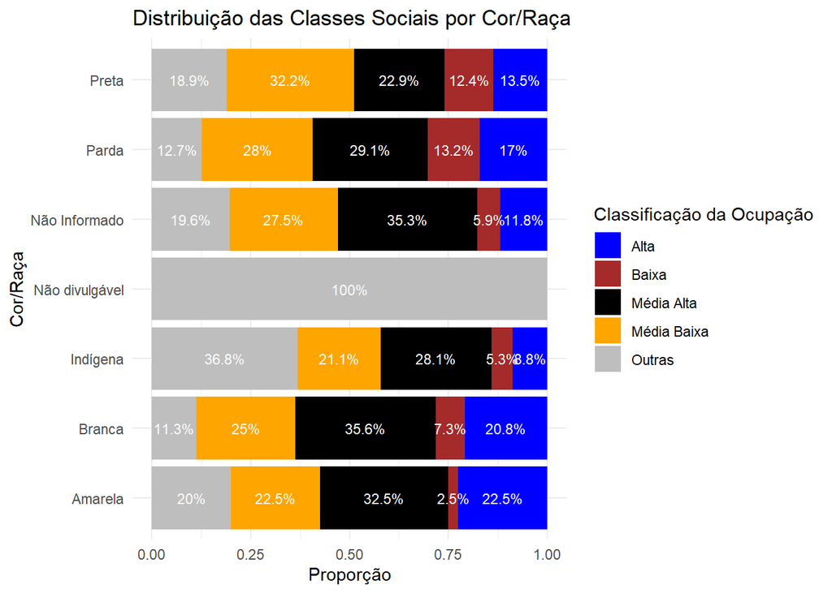

```r
#Gráfico de barras empilhadas
ggplot(classificacao_percent, aes(x = Cor_raca, y = n, fill = Classificacao_ocupacao)) +
  geom_bar(stat = "identity", position = "fill") +
  coord_flip() +
  scale_fill_manual(values = c("Alta" = "blue", "Baixa" = "brown", "Média Alta" = "black", "Média Baixa" = "orange", "Outras" = "grey")) +
   geom_text(aes(label = paste0(round(percentage, 1), "%")),
            position = position_fill(vjust = 0.5),
            color = "white",
            size = 3) +
  labs(title = "Distribuição das Classes Sociais por Cor/Raça",
       x = "Cor/Raça",
       y = "Proporção",
       fill = "Classificação da Ocupação") +
  theme_minimal()
```